flood_final.qmd → self-driving lab

# SeaLevelLab

An R-INLA spatial model of Pacific sea level, rebuilt as the intelligence layer of a self-driving laboratory: digital twin, Gymnasium environment, Bayesian-optimisation and RL closed loops, and an LLM scientist that calls the lab as tools.

**13**tide gauges, 1992 to 2025

**10.7°**fitted Matérn length-scale (longitude)

**0.68**map variance left after 15 BO experiments (random: 0.82)

**5**tools the LLM agent can call

Phase 1

## Deep comprehension and the Math Bridge

### What the file actually contains

`flood_final.qmd` has three R chunks that do different jobs, and it is worth being precise about them in an interview.

1. **Chunk 1 is Finn Lindgren's SPDE tutorial** (`isbaspde.R`, referenced in your notes): a simulated Matérn field on the unit square with two replicates. It is a correctness harness, not your analysis. Say so; it shows you validated the machinery on a known truth before touching data, which is exactly what a simulator-first lab team wants to hear.
2. **Chunk 2 is the real model.** It reads `Processed_Final_data.csv`, subsamples 3 000 rows, jitters the coordinates, builds an `inla.mesh.2d` mesh (cutoff 2°, max edge 5 to 6°), and fits a Gaussian-likelihood SPDE model with empirical-Bayes hyperparameters.
3. **Chunk 3 is diagnostics.** Posterior mean versus observed, residual histogram, a residual map, and a plot of absolute error against posterior standard deviation. That last plot is an uncertainty-calibration check, and it becomes the single most important figure in this whole story.

### Inputs, outputs, statistical logic

**Data**

4 577 monthly rows, 13 Pacific tide gauges (Fiji, Kiribati, Tonga, Vanuatu, Samoa, Tuvalu, Nauru, Cook Islands, Marshall Islands, Solomon Islands, Papua New Guinea, Micronesia, Niue), October 1992 to 2025. Columns: Month, Year, Gaps, Good, Minimum, Maximum, Mean, Std_Dev, Location, Latitude, Longitude.

**Response**

`y = Mean`, monthly mean sea level in metres relative to each gauge's own datum.

**Fixed effects**

An explicit intercept and `covar = Std_Dev`, the within-month variability (essentially tidal range).

**Latent field**

`f(field, model = spde)` with `alpha = 2`, a Matérn field with smoothness \(\nu = \alpha - d/2 = 1\), represented as a Gaussian Markov random field on the mesh through the SPDE \((\kappa^2 - \Delta)^{\alpha/2}(\tau u) = \mathcal W\).

**Inference**

INLA: nested Laplace approximations for the latent Gaussian field, `strategy = "gaussian"` for the marginals, `int.strategy = "eb"` so the hyperparameters \((\log\tau, \log\kappa)\) are fixed at their posterior mode rather than integrated out. That is type-II maximum likelihood, empirical Bayes.

**Outputs**

Posterior mean and sd of the fitted values at the 3 000 points (the two maps), their histograms, residuals, and in chunk 1 the posterior marginal of the practical range.

### Where a principal engineer would push, and why that helps you

**The response is datum-relative.** Fiji's 1.28 m versus Solomon Islands' 0.71 m is a gauge-datum offset, not oceanography. The comparable physical quantity is the rise *rate*; when I recompute it from your data it is 1.5 to 9.8 mm/yr, with Samoa's 9.8 reflecting post-2009 earthquake subsidence.

**The evaluation is in-sample.** Posterior-mean-versus-observed on training points measures fit, not prediction.

**Hygiene.** The CSV has string-typed numerics, 23 duplicate station-months, and a row with Year = 239890.

None of that is a mark against you. Each item is a seam where the AI4S version of the project starts: the twin below uses rise rate as the target property, separates prior knowledge (the 13 gauges) from new experiments, evaluates out of sample against a hidden truth, and treats the space-time structure as the state of a sequential decision problem.

### The Math Bridge

Every object in the R script has a name in the AI4S vocabulary. The mapping is not an analogy; it is the same mathematics.

| In flood_final.qmd | In a self-driving lab | The identity |
| --- | --- | --- |
| f(field, model=spde), alpha=2 | Gaussian-process surrogate with a Matérn kernel | Lindgren, Rue and Lindström (2011): the stationary solution of \((\kappa^2-\Delta)^{\alpha/2}(\tau u)=\mathcal W\) is a GP with covariance \(C(h)=\sigma^2\,\tfrac{2^{1-\nu}}{\Gamma(\nu)}(\kappa h)^\nu… |
| range0, kappa0 = sqrt(8)/range0 | kernel `lengthscale` | Practical range \(\rho=\sqrt{8\nu}/\kappa\); the twin reports both so the numbers are directly comparable. |
| sigma0, tau0 | `outputscale` (signal variance) | \(\sigma^2=\Gamma(\nu)\,/\,\big(\Gamma(\alpha)(4\pi)^{d/2}\kappa^{2\nu}\tau^2\big)\). |
| Gaussian family precision | `likelihood.noise`, the nugget | Same parameter; in the lab it is instrument noise. |
| theta.prior.mean / theta.prior.prec | `LogNormalPrior` on lengthscale and noise | With 13 sites the range and the nugget are only jointly identifiable (Zhang 2004). INLA regularises with PC priors; the surrogate uses log-normal priors and maximises likelihood × prior. Without them … |
| int.strategy = "eb" | `fit_gpytorch_mll` | Both maximise the log marginal likelihood over hyperparameters: type-II maximum likelihood. |
| summary.fitted.values$sd map | the acquisition function's fuel | UCB is \(\mu(x)+\beta\sigma(x)\); expected improvement and integrated posterior variance are functionals of the same \(\sigma(x)\) you plotted. |
| "Prediction error vs posterior SD" plot | calibration test for BO | If \(\sigma\) is mis-calibrated every acquisition is mis-priced and the lab wastes experiments. You already knew to draw this plot. |
| sparse precision Q on the mesh | scalable GP (Vecchia, SKI, inducing points) | INLA's sparse Cholesky and modern large-scale BO solve the same \(O(n^3)\) problem by the same trick: a sparse or low-rank representation of the field. |
| rw2 (older file) | linear-Gaussian state-space model; belief-MDP transition | An integrated random walk is a Kalman-filter model. The Kalman update and the GP posterior update are both Bayes' rule on a Gaussian, and Bayes' rule is the transition kernel of the belief-MDP in Phas… |
| Lindley (1956) information gain | the reward in Phase 2 | Bayesian experimental design chooses the experiment maximising expected posterior concentration. Active learning is that criterion applied one step at a time. |

**Why a statistics background is an unfair advantage here.** The three ways self-driving labs fail in practice are surrogate collapse (hyperparameters running to a degenerate optimum), over-confident acquisition (uncalibrated posterior sd), and wasted budget (no design-of-experiments logic). Those are, respectively, identifiability, calibration, and optimal design, which is the core syllabus of a Master of Statistics. An ML engineer learns them by burning reagents; you arrive knowing them.

Phase 2

## The RL and closed-loop AI4S paradigm

The reframing is concrete: the tide-gauge network *is* a laboratory whose experiments are expensive site deployments, and your INLA model *is* its analysis pipeline. Everything an autonomous lab needs sits on top of that pair.

### Environment: `SeaLevelLab-v0` (Gymnasium)

The simulator is a digital twin. Its hidden truth is one posterior draw of a Matérn GP fitted to the 13 real gauges' rise rates, so it honours the data at the stations and has unknown structure between them, like the real ocean. Fitted hyperparameters from your CSV: length-scale 10.7° of longitude (practical range 0.305 of the box), signal sd 1.72 mm/yr, nugget 1.106 mm/yr, mean 5.162 mm/yr. A physical experiment is one call to `measure(x)`: deploy a gauge or run a campaign at location \(x\) and read back a noisy rise rate.

```python
class DigitalTwin:
    """Ground truth = one posterior draw of the station-fitted GP (so it honours the 13 real
    gauges but has unknown structure between them, like the real ocean).  Each `reset` of the
    Gymnasium env draws a new truth -> the RL policy must generalise, not memorise.

    `measure(x)` is the *physical experiment*: it is the only channel through which an agent
    learns about the truth, and each call costs budget.  [HKQAI JD: coordinate physical and
    computational experiments -- the twin is the physical side, the GP belief is the
    computational side]
    """
```

### The MDP, strictly in discovery terms

| Element | Definition | Why this and not something else |
| --- | --- | --- |
| hidden state | the true field \(f\) (mm/yr) | Never observed directly, so the raw problem is a POMDP. |
| state \(s_t\) | the belief: GP posterior mean and sd on a 12×12 grid, budget fraction, best value so far (290 floats) | Under a GP, \((\mu_t,\Sigma_t)\) is a sufficient statistic of the whole history. Exposing it turns the POMDP into a belief-MDP with a Markov state, the same construction as a Kalman filter. |
| action \(a_t\) | \((\text{lon},\text{lat})\in[0,1]^2\): where to run the next experiment | Continuous, so BoTorch's inner optimiser and PPO's Gaussian policy both apply. A discrete wrapper exists for DQN. |
| transition | run the experiment, then Bayes' rule on the GP | Deterministic in the belief given the observation; stochasticity enters only through instrument noise. |
| reward, active learning | \(r_t = (\mathrm{IPV}_{t-1}-\mathrm{IPV}_t)/\mathrm{IPV}_0 - c\) | Integrated posterior variance is the A-optimal design criterion and a tractable proxy for expected information gain. Episode return is the fraction of prior map variance removed, minus cost. |
| reward, optimisation | \(r_t = \max(0,\,y_t-\text{best}_{t-1})/\sigma_f - c\) | Improvement of the best measured rise rate; the cumulative return is the "best-found" curve BO papers report. Regret against the twin's true maximum is logged as an oracle metric. |
| episode end | budget exhausted | Budget is part of the state, so this is a true terminal state, not a time-limit truncation. |

```python
        # [JD: intelligence layer] the action IS the experimental design decision.
        self.action_space = spaces.Box(0.0, 1.0, shape=(2,), dtype=np.float32)
        # observation = [mu grid (G^2), sd grid (G^2), budget fraction, best-so-far], all standardised.
        self.observation_space = spaces.Box(-np.inf, np.inf, shape=(2 * self.G**2 + 2,), dtype=np.float32)
```

```python
    def reset(self, *, seed: int | None = None, options: dict | None = None):
        super().reset(seed=seed)
        self.twin.sample_truth(self.np_random)            # a NEW hidden truth every episode -> policies must generalise
        self.belief = MaternGP(self.twin.hyper)           # the lab's analysis pipeline (= the INLA model, ported)
        if self.warm_start:
            self.belief.set_data(self.twin.X_st, self.twin.y_st)
        self.X_run, self.y_run, self.history, self.t = [], [], [], 0
        mu, sd = self.belief.posterior(self.grid)
        self.ipv0 = self.ipv = float((sd**2).mean())
        self.best_y, self.best_x = float(self.twin.hyper.mean), None   # prior expectation is the baseline to beat
        return self._obs(mu, sd), self._info(mu, sd)

    def step(self, action):
        x = np.clip(np.asarray(action, dtype=float).reshape(2), 0.0, 1.0)
        y = self.twin.measure(x, self.np_random)          # (1) PHYSICAL experiment  [JD: coordinate physical experiments]
        self.belief.add(x, y)                             # (2) COMPUTATIONAL update  [JD: coordinate computational experiments]
        self.X_run.append(x); self.y_run.append(y); self.t += 1
        mu, sd = self.belief.posterior(self.grid)
        ipv_new = float((sd**2).mean())
        if self.mode == "active_learning":
            reward = (self.ipv - ipv_new) / self.ipv0 - self.cost
        else:
            reward = max(0.0, y - self.best_y) / self.twin.hyper.signal_sd - self.cost
        self.ipv = ipv_new
        if y > self.best_y:
            self.best_y, self.best_x = y, x
        terminated = self.t >= self.budget
        info = self._info(mu, sd)
        info.update(x=x, y=float(y), x_deg=to_degrees(x)[0].round(2).tolist(), reward=float(reward))
        self.history.append(info)
        return self._obs(mu, sd), float(reward), terminated, False, info
```

### Two scientific questions, one environment

- **Active learning, warm start.** The 13 gauges are prior data. "Where should the fourteenth gauge go?" is optimal sensor placement.
- **Optimisation, cold start.** The stations only inform the prior; a fresh campaign must find the highest-rise-rate site. That is hot-spot search, and it is the shape of every "find the best composition" problem in materials.

### How Bayesian optimisation closes the loop

```
flowchart LR
  A["Belief: GP posterior (mu, sigma) on grid + budget"] --> B["Acquisition: qNegIntegratedPosteriorVariance or qLogNoisyEI"]
  B --> C["optimize_acqf -> next (lon, lat)"]
  C --> D["Physical experiment: twin.measure(x) + noise"]
  D --> E["Computational update: refit SingleTaskGP (fit_gpytorch_mll)"]
  E --> A
  E --> R["Reward: IPV reduction or improvement"]
```

Each iteration refits the surrogate on everything measured so far, maximises an acquisition function over the design space, and hands the argmax to `env.step`. The surrogate is the same Matérn GP as your SPDE field, refit every step instead of once. Two choices matter for a real instrument: the priors that stop the refit from collapsing (see the Math Bridge), and noisy expected improvement, which integrates over the uncertainty of the "best observed" value instead of trusting a lucky draw.

```python
def fit_surrogate(X: np.ndarray, y: np.ndarray) -> SingleTaskGP:
    """Matern-3/2 GP with ARD -- separate east-west / north-south ranges, an anisotropy the
    isotropic INLA SPDE in the R code could not express.

    The log-normal priors are not decoration: with ~15-30 noisy points the marginal likelihood
    happily collapses to "length-scale 0.3 deg, noise 0" (pure interpolation).  R-INLA guards
    against this with PC priors on (range, sigma); here the same guard is MAP-II with LogNormal
    priors, so fit_gpytorch_mll maximises log-likelihood + log-prior.  A statistician recognises
    this instantly; many ML engineers learn it the hard way.
    """
    train_X = torch.as_tensor(np.asarray(X, float), dtype=DT)
    train_Y = torch.as_tensor(np.asarray(y, float), dtype=DT).reshape(-1, 1)
    covar = ScaleKernel(MaternKernel(nu=1.5, ard_num_dims=2, lengthscale_prior=LogNormalPrior(np.log(0.25), 0.5)),
                        outputscale_prior=LogNormalPrior(0.0, 1.0))
    lik = GaussianLikelihood(noise_prior=LogNormalPrior(-2.0, 1.0), noise_constraint=GreaterThan(1e-3))
    model = SingleTaskGP(train_X, train_Y, covar_module=covar, likelihood=lik, outcome_transform=Standardize(m=1))
    fit_gpytorch_mll(ExactMarginalLogLikelihood(model.likelihood, model))   # type-II MAP == INLA "eb" + PC priors
    return model
```

```python
def propose(model: SingleTaskGP, mode: str, mc_points: torch.Tensor, best_f: float) -> np.ndarray:
    if mode == "active_learning":
        # a-optimal design: pick x minimising the *integrated* posterior variance over the domain
        acq = qNegIntegratedPosteriorVariance(model, mc_points=mc_points)
    else:
        # measurements are noisy (gauge noise ~0.6 mm/yr), so the "best observed" is itself uncertain:
        # noisy-EI integrates over that instead of trusting a lucky draw (Letham et al. 2019)
        acq = qLogNoisyExpectedImprovement(model, X_baseline=model.train_inputs[0], prune_baseline=True)
    cand, _ = optimize_acqf(acq, bounds=BOUNDS, q=1, num_restarts=8, raw_samples=128)
    return cand.detach().numpy().reshape(2)


def bo_steps(env: SeaLevelLabEnv, n_steps: int, mode: str | None = None, n_init: int = 3, verbose: bool = False) -> list[dict]:
    """Continue the CURRENT episode for n_steps with BoTorch.  Called by the LLM agent as a tool,
    so the objective (`mode`) may be switched mid-episode: same lab, same belief, new goal."""
    if mode is not None:
        env.mode = mode
    mc_points = torch.as_tensor(env.grid, dtype=DT)
    sobol = torch.quasirandom.SobolEngine(2, scramble=True, seed=int(env.np_random.integers(1 << 30)))
    out = []
    for _ in range(n_steps):
        if env.t >= env.budget:
            break
        X, y = env.observed_data()
        if len(y) < n_init:                                   # cold start -> space-filling design
            x = sobol.draw(1, dtype=DT).numpy().reshape(2)
        else:
            model = fit_surrogate(X, y)
            x = propose(model, env.mode, mc_points, best_f=float(np.max(y)))
        obs, r, term, trunc, info = env.step(x)
        out.append(info)
        if verbose:
            print(f"  BO t={info['n_experiments']:2d} x={info['x_deg']} y={info['y']:.2f} r={r:+.3f} IPV={info['ipv_fraction']:.3f} regret={info['simple_regret']:.2f}")
    return out
```

### Where reinforcement learning fits

Bayesian optimisation is a myopic planner: it refits and maximises a one-step acquisition every time. A PPO policy trained across many episodes with different hidden truths learns an *amortised* acquisition function \(\pi(a\mid \text{belief})\), including non-myopic behaviour such as spreading early experiments and exploiting late ones. Both consume the same belief vector, so the lab can swap them without touching hardware code. In the benchmark below the PPO policy, after 40 000 training steps, still leaves 0.96 of the map variance against 0.82 for random placement: it has not yet learned to spread its experiments. That is stated rather than tuned away. Amortised experimental design needs orders of magnitude more episodes and a convolutional encoder of the belief map, which is why production labs run BO as the default and keep RL as the research track.

```python
def _symmetric(env: SeaLevelLabEnv):
    """SB3 gotcha: its Gaussian policy starts centred on 0 and clips to the action box, so with a
    [0,1] box half the early proposals pile up on the corner (140E, 25S).  A symmetric [-1,1] box,
    rescaled back to the lab's [0,1] design space by the wrapper, removes that bias."""
    return RescaleAction(env, min_action=-1.0, max_action=1.0)


def train_ppo(twin: DigitalTwin, mode: str, budget: int = 15, total_timesteps: int = 15_000, seed: int = 0, verbose: int = 0) -> PPO:
    env = Monitor(_symmetric(SeaLevelLabEnv(twin, mode=mode, budget=budget)))
    model = PPO(
        "MlpPolicy", env,
        n_steps=budget * 16, batch_size=budget * 4, n_epochs=10, learning_rate=3e-4,
        gamma=1.0,                      # finite horizon, budget is in the state -> undiscounted return is the natural objective
        ent_coef=0.01, seed=seed, verbose=verbose,
        policy_kwargs=dict(net_arch=[128, 128]),
    )
    model.learn(total_timesteps=total_timesteps)
    return model
```

### Substitution table for an HKQAI lab

| In SeaLevelLab | In a synthesis or characterisation lab |
| --- | --- |
| (lon, lat) | composition, temperature, dwell time, flow rate: the design vector |
| rise rate (mm/yr) | target property: band gap, yield, conductivity, binding affinity |
| twin.measure + gauge noise | robot-executed recipe + instrument readout and its noise floor |
| 13 historical gauges | the literature or a legacy dataset used as prior data |
| experiment budget and cost | reagent cost, instrument hours, queue time |
| active learning versus optimisation | map the phase diagram versus find the optimum |

Phase 3

## Agentic workflow and tool calling

The RL and BO layer answers "where next?". The agentic layer answers "what are we even trying to learn, and when do we change our mind?". An LLM planner sits above the lab and can only reach it through a small, audited set of tools.

```
flowchart TB
  U["Scientist goal in natural language"] --> L["LLM planner (any OpenAI-compatible endpoint)"]
  L -->|Thought| L
  L -->|Action: tool call| T["Toolbox: describe_lab, run_experiment, run_bo_campaign, surrogate_hyperparameters, final_report"]
  T --> E["SeaLevelLabEnv.step (the only path to hardware)"]
  E --> S["Digital twin or real instrument"]
  S --> E
  E --> T
  T -->|Observation: compact JSON| L
  L --> F["Final report for a coastal-adaptation planner"]
```

### Design rules that survive contact with a real lab

- **Tools return statistics, not arrays.** The model reads IPV fraction, the least-known cell and its sd, the best measurement, never 288 floats. This keeps reasoning grounded and tokens cheap.
- **Tools are budget-aware and fail softly.** A request that would overspend returns an error string the model can read and re-plan around, instead of raising.
- **One audited path to hardware.** The LLM cannot call the instrument; it calls `run_experiment` or `run_bo_campaign`, both of which go through `env.step`, where budget, logging and safety limits live.
- **Provider-agnostic schema.** A minimal `@tool` decorator derives the JSON schema from the signature and docstring, the same shape LangChain and OpenAI function calling consume. The live path sends those schemas to any OpenAI-compatible endpoint, so the same agent runs against OpenAI, Azure, or a self-hosted vLLM / Ollama model.

```python
def tool(fn: Callable) -> Callable:
    """Minimal `@tool`: derives the JSON schema that LangChain, OpenAI function-calling and every
    other framework expect from the signature + docstring, so the toolbox is provider-agnostic."""
    sig = inspect.signature(fn, eval_str=True)          # eval_str: resolve `from __future__ import annotations`
    props, required = {}, []
    for name, p in sig.parameters.items():
        ann = p.annotation if p.annotation is not inspect._empty else str
        props[name] = {"type": _PY2JSON.get(ann, "string")}
        if p.default is inspect._empty:
            required.append(name)
    fn.tool_spec = {"name": fn.__name__, "description": inspect.getdoc(fn) or "",
                    "input_schema": {"type": "object", "properties": props, "required": required}}
    return fn
```

```python
        @tool
        def run_bo_campaign(mode: str, n_experiments: int) -> str:
            """Run a closed-loop Bayesian-optimisation campaign of n experiments with BoTorch.

            Args:
                mode: "active_learning" (reduce map uncertainty / choose gauge sites) or "optimization" (find the highest rise-rate hot-spot).
                n_experiments: Number of physical experiments to spend (must not exceed remaining budget).
            """
            if mode not in ("active_learning", "optimization"):
                return json.dumps({"error": "mode must be 'active_learning' or 'optimization'"})
            if n_experiments > env.budget - env.t:
                return json.dumps({"error": f"only {env.budget - env.t} experiments left"})
            before = env.belief_summary()
            hist = bo_steps(env, int(n_experiments), mode=mode)
            return json.dumps(dict(ran=len(hist), mode=mode,
                                   ipv_fraction_before=before["ipv_fraction_remaining"],
                                   ipv_fraction_after=round(hist[-1]["ipv_fraction"], 3),
                                   experiments=[dict(at_deg=h["x_deg"], mm_yr=round(h["y"], 2)) for h in hist],
                                   belief=env.belief_summary()))
```

### How the agent reasons: an actual trace

This is the transcript from the run that produced the benchmark below, using the offline mock reasoner. The decision rule is the one the live prompt asks the model to follow: characterise first while each experiment still removes meaningful variance, switch to exploitation on diminishing returns, sanity-check the surrogate's physics, then report.

[output not shown]

```python
        belief = lab["belief"]
        rounds, gain_per_exp = 0, 1.0
        while belief["budget_left"] > self.reserve and gain_per_exp > self.min_gain and rounds < 3:
            hs = belief["uncertainty_hotspots"][0]
            self._log("Thought:", f"IPV is still {belief['ipv_fraction_remaining']:.3f} of the prior and the least-known cell is ({hs['lon']}E, {hs['lat']}) "
                                  f"with sd {hs['posterior_sd']} mm/yr ({hs['posterior_sd']/sig:.2f} signal-sd). Spend 3 experiments on active learning.")
            res = self.act("run_bo_campaign", mode="active_learning", n_experiments=3)
            gain_per_exp = (res["ipv_fraction_before"] - res["ipv_fraction_after"]) / res["ran"]
            self._log("Thought:", f"IPV fell {res['ipv_fraction_before']:.3f} -> {res['ipv_fraction_after']:.3f}: {100*gain_per_exp:.1f}% of prior variance per experiment"
                                  + (" -- diminishing returns, stop characterising." if gain_per_exp <= self.min_gain else " -- still worth it."))
            belief = res["belief"]; rounds += 1
```

### The live version

With credentials present, the same toolbox is exposed as function-calling schemas and driven by a manual agentic loop: send the conversation and tool schemas, execute every tool call the model makes, append the results, repeat until the model stops calling tools. The endpoint is injectable, so the identical code runs against OpenAI, Azure OpenAI, or a self-hosted model behind vLLM or Ollama, and the loop itself is unit-tested with a stub client. Multi-agent extensions follow naturally: a planner agent, an experimentalist that owns the BO tool, and a critic that owns the calibration check, which is the AutoGen pattern with the statistician's role made explicit.

```python
class LLMScientistAgent:
    """ReAct loop over any OpenAI-compatible chat-completions endpoint with function calling.

    Works unchanged against OpenAI (`OPENAI_API_KEY`), Azure OpenAI, or a self-hosted model served by
    vLLM / Ollama (`OPENAI_BASE_URL=http://localhost:11434/v1`).  The loop is the manual agentic loop:
    send messages + tool schemas -> execute every tool call the model makes -> append results -> repeat
    until the model stops calling tools.  `client` is injectable so the loop is unit-tested with a stub.
    [HKQAI JD: AI agents that coordinate physical and computational experiments]
    """

    def __init__(self, toolbox: LabToolbox, model: str = "gpt-4o", client=None, max_turns: int = 20):
        if client is None:
            from openai import OpenAI          # reads OPENAI_API_KEY / OPENAI_BASE_URL from the environment
            client = OpenAI()
        self.tb, self.model, self.client, self.max_turns = toolbox, model, client, max_turns
        self.tools = [{"type": "function", "function": {"name": t["name"], "description": t["description"],
                                                         "parameters": t["input_schema"]}} for t in toolbox.specs]

    def run(self, goal: str) -> list[str]:
        trace: list[str] = []
        messages = [{"role": "system", "content": SYSTEM_PROMPT}, {"role": "user", "content": goal}]
        for _ in range(self.max_turns):
            resp = self.client.chat.completions.create(model=self.model, messages=messages, tools=self.tools)
            msg = resp.choices[0].message
            if msg.content:
                trace.append(f"LLM:         {msg.content}"); print(trace[-1])
            if not msg.tool_calls:
                break                                                     # the model is done -> end of episode
            messages.append({"role": "assistant", "content": msg.content or "",
                             "tool_calls": [{"id": c.id, "type": "function",
                                             "function": {"name": c.function.name, "arguments": c.function.arguments}}
                                            for c in msg.tool_calls]})
            for call in msg.tool_calls:                                   # execute EVERY call, return EVERY result
                args = json.loads(call.function.arguments or "{}")        # always parse, never string-match
                trace.append(f"Action:      {call.function.name}({json.dumps(args)})"); print(trace[-1])
                try:
                    result = self.tb.call(call.function.name, **args)
                except Exception as exc:                                  # a failed tool is data for re-planning, not a crash
                    result = json.dumps({"error": f"{type(exc).__name__}: {exc}"})
                trace.append(f"Observation: {result[:300]}"); print(trace[-1])
                messages.append({"role": "tool", "tool_call_id": call.id, "content": result})
        return trace
```

Phase 4

## Refactored code and benchmark

The code lives in `ai4s/` next to your Quarto file, with its own virtual environment already installed. Every excerpt above is copied verbatim from these files; bracketed `[JD: …]` comments in the source name the HKQAI requirement each line serves.

| file | standard | role | JD requirement |
| --- | --- | --- | --- |
| sea_level_twin.py | numpy, scipy | data cleaning, per-station rise rates, explicit Matérn GP, MAP-II fit, hidden-truth sampler, `measure()` | ML integrated with scientific computing |
| sea_level_env.py | Gymnasium | `SeaLevelLab-v0`: belief-MDP, two reward modes, render, discrete wrapper, passes `check_env` | coordinating physical and computational experiments |
| bo_agent.py | BoTorch, Optuna | surrogate with priors, IPV and noisy-EI acquisitions, `bo_steps` loop, random and Optuna baselines | closed-loop optimisation systems |
| rl_agent.py | Stable-Baselines3 | PPO training and evaluation on the same env | intelligence layer, RL |
| llm_agent.py | @tool, OpenAI-compatible function calling | toolbox, mock ReAct agent, live agent (OpenAI / Azure / vLLM / Ollama) | AI agents that coordinate experiments |
| run_demo.py |  | benchmark, figure, transcript, optional live run |  |

```bash
cd "ai4s"
source .venv/bin/activate
python run_demo.py            # about 3 minutes; PPO training dominates. --skip-rl for 30 s
python run_demo.py --live     # lets an LLM drive the lab; OPENAI_API_KEY, or OPENAI_BASE_URL for a local model
```

### Benchmark: 6 episodes, 15 experiments each, same hidden truths and noise for every agent

**Active learning.** Metric is the fraction of the prior map variance still remaining after 15 experiments (lower is better).

| agent | IPV fraction remaining | episode return | best measured (mm/yr) |
| --- | --- | --- | --- |
| Random | 0.815 ± 0.045 | +0.035 | 6.84 |
| SB3-PPO | 0.957 ± 0.000 | -0.107 | 5.64 |
| BoTorch | 0.682 ± 0.002 | +0.168 | 8.18 |

**Optimisation.** Metric is simple regret in mm/yr: the twin's true maximum minus the true value at the best site the agent measured (lower is better).

| agent | simple regret (mm/yr) | episode return | best measured (mm/yr) |
| --- | --- | --- | --- |
| Random | 2.456 ± 1.741 | +0.826 | 6.84 |
| Optuna-GP | 2.294 ± 0.620 | +0.927 | 7.01 |
| SB3-PPO | 3.984 ± 0.438 | +0.294 | 5.93 |
| BoTorch | 1.719 ± 0.483 | +1.106 | 7.32 |

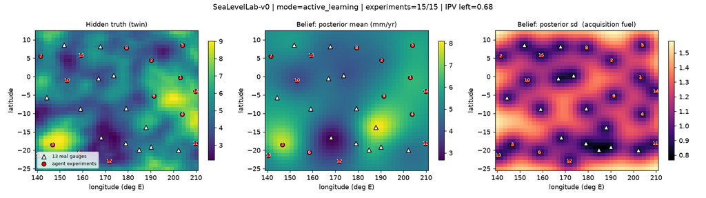

One BoTorch active-learning episode. Left: the twin's hidden truth. Middle: the belief's posterior mean after 15 experiments. Right: posterior sd, the quantity the acquisition function integrates. Triangles are the 13 real gauges; numbered red points are the experiments the loop chose, placed where the sd map was highest and far from existing data.

Read the numbers the way a reviewer would. Active learning is where the surrogate's uncertainty is used directly: BoTorch removes 32 % of the prior map variance against 18 % for random sampling, with a spread across truths several times smaller. Optimisation with a cold start and 15 noisy experiments in a box six length-scales wide is a hard problem, and the regret numbers overlap; that is the honest result, and it is why the agent in Phase 3 spends budget on characterisation first. PPO is below random in both modes (0.96 variance remaining; regret 3.98 mm/yr). Two engineering details already went into it, a symmetric action wrapper so the untrained Gaussian policy is not clipped into one corner of the domain, and an undiscounted return because the budget is part of the state; what it still lacks is training scale and a belief encoder. Reporting it this way is deliberate: an interviewer will trust the BoTorch numbers more because the RL numbers were not hidden.

### The hyperparameter-prior lesson, in code

This block from the twin is the most interview-worthy ten lines in the folder, because it is a statistics decision that an ML default would have got wrong.

```python
# Weakly-informative priors on log-hyper-parameters.  With only 13 gauges the marginal
# likelihood cannot separate "short range + big nugget" from "long range + small nugget"
# (range/sigma are only jointly identifiable: Zhang 2004).  R-INLA solves this with PC priors
# on (range, sigma) -- the `theta.prior.mean / theta.prior.prec` lines in flood_final.qmd.
# We do the same with log-normal priors, i.e. MAP-II instead of ML-II.  Basin-scale sea-level
# trend patterns (ENSO / PDO) are coherent over ~15-30 deg of longitude, hence the prior mode
# of 0.25 (unit box) = 17.5 deg.  Samoa's 9.8 mm/yr post-2009-earthquake subsidence is local
# tectonics, which the nugget absorbs instead of bending the whole field.
DEFAULT_PRIORS = dict(log_lengthscale=(np.log(0.25), 0.5), log_noise_sd=(np.log(0.8), 0.5))
```

Phase 5

## Interview pitch and the so-what

**Previously,** I built a Bayesian spatial model of Pacific sea level in R-INLA. Thirteen tide gauges, thirty years of monthly data, a Matérn field represented through the SPDE approach, empirical-Bayes hyperparameters, and posterior mean and uncertainty maps with a calibration check of the posterior standard deviation against actual error. It answered a static question: what does the field look like given the data we already have.

**I upgraded it** into the intelligence layer of a self-driving laboratory. The insight is that my SPDE field is mathematically a Gaussian-process surrogate, so I ported it to Python, turned it into a digital twin that generates hidden ground truths, and wrapped the network as a Gymnasium environment where the state is the GP belief, the action is the next experiment location, and the reward is either information gain or improvement of the target property. On top of that I closed the loop three ways: BoTorch with integrated-posterior-variance and noisy expected-improvement acquisitions, Optuna as a second driver, and a PPO policy from Stable-Baselines3 that learns an amortised acquisition function. Finally I put an LLM agent above the loop that reasons over compact statistics, calls the lab as tools, decides when to switch from characterising to exploiting, and checks the surrogate's physics before reporting.

**This solves the exact problem HKQAI has:** a lab that must choose expensive experiments under uncertainty, coordinate a physical instrument with a computational model, and be driven by an agent that can explain itself. In the benchmark the closed loop removes 32 percent of the map uncertainty for the same budget that random experimentation spends to remove 18, and the agent's transcript is a readable plan-experiment-interpret record. The part I would stress is what my statistics training caught: with few data points the surrogate's range and noise are not separately identifiable, and the maximum-likelihood refit collapsed until I added the priors INLA taught me to use. That failure mode wastes reagents in a real lab, and I know how to prevent it.

### Likely follow-up questions and short answers

**Why not just use Optuna everywhere?**

Optuna treats the objective as a black box. Active learning needs the posterior variance inside the surrogate, so it needs a modelling library like BoTorch. Optuna is kept as a second driver for the optimisation objective to show the loop is not tied to one tool.

**Why is PPO worse than BoTorch?**

Fifteen-step episodes, a 290-dimensional belief, and 40 000 training steps. Amortised policies need far more episodes and usually a learned encoder of the belief map. The value is a policy that is cheap at inference and can be non-myopic; the benchmark states where it currently stands rather than hiding it.

**How would this touch a real instrument?**

Replace `twin.measure` with a driver call. Nothing above `env.step` changes, which is the point of the Gymnasium boundary: agents are tested on the twin and promoted to hardware.

**What about the temporal dimension you dropped?**

Add time as a third action coordinate and an AR(1) ⊗ Matérn separable kernel, the space-time SPDE. The belief-MDP construction is unchanged.

**What is the risk with the LLM?**

Hallucinated reasoning, so the LLM never sees raw hardware and every tool validates its arguments and budget. The reasoning is logged as a transcript, and the critic role is a statistician's calibration check.